# ESM 204 - Assignment 2

Conner Smith, Tommy King, Charlie Wilson

4/13/2022

```r
knitr::opts_chunk$set(echo = TRUE, message = FALSE, warning = FALSE, options(scipen = 999))

library(tidyverse)
library(here)
library(janitor)
library(thematic)
library(scales)
library(equatiomatic)

thematic::thematic_rmd()
thematic::thematic_on()
```

## Overview

```r
# Read in the main data set

districts <- read_csv(here("Water_Districts.csv")) %>%
  clean_names() %>%
  select(-x1)
```

Agricultural water is managed by irrigation districts and is increasingly scarce. To conserve water and reduce costs, four irrigation districts are considering developing a water market, in which water rights would be traded across the districts. In this homework you will conduct data analysis, simulations, and policy analysis to help inform the development of the water market.

## **Analysis**

The dataset contains estimates of the marginal cost of reducing water use in each of the four irrigation districts (Kern, Mojave, Antelope, and Ventura) for different levels of reduction (in Acre Feet).

Current (i.e. baseline) water use in these districts is:

- Kern = 150 AF
- Mojave = 140 AF
- Antelope = 220 AF
- Ventura = 245 AF

Prices are in $/Acre Foot and quantities are in Acre Feet (AF).

### **1. Abatement Costs**

For each irrigation district, plot the marginal abatement cost data (from the data provided) and estimate a linear regression model with zero intercept. These estimated linear regressions will be your estimates of the marginal abatement cost curve (one for each irrigation district), which you will use for the remainder of this analysis.

#### **Figure 1: MC Across Counties**

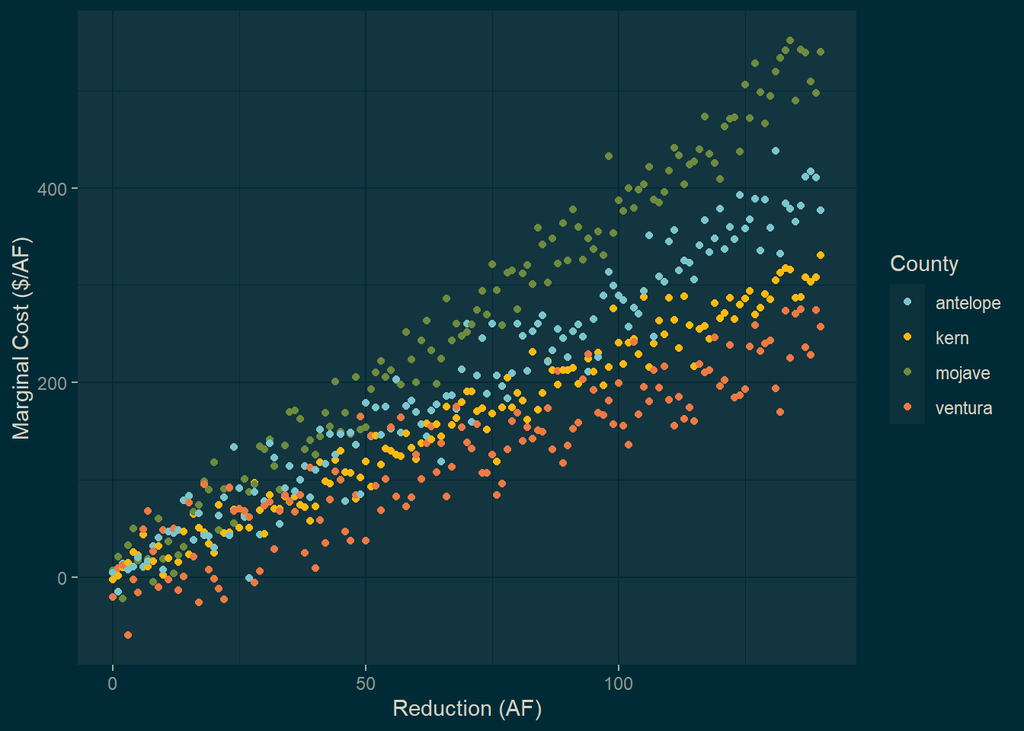

```r
districts_sub <- districts %>%
  rename(kern = mc_kern,
         mojave = mc_mojave,
         antelope = mc_antelope,
         ventura = mc_ventura) %>%
  pivot_longer(cols = c(kern, mojave, antelope, ventura),
               names_to = 'county',
               values_to = 'mc')

ggplot(data = districts_sub, aes(x = reduction, y = mc)) +
  geom_point(aes(color = county)) +
  scale_color_manual("County",
                     values = c('cadetblue3', 'darkgoldenrod1',
                     'darkolivegreen4', 'sienna2')) +
  labs(x = "Reduction (AF)", y = "Marginal Cost ($/AF)")
```

```r
# Linear model for Kern MC forcing 0 intercept

lm_kern <- lm(mc_kern ~ 0 + reduction, data = districts)
extract_eq(model = lm_kern, use_coefs = TRUE)
```

$$\operatorname{\widehat{mc\_kern}} = 2.29(\operatorname{reduction})$$

```r
# Linear model for Mojave MC forcing 0 intercept

lm_mojave <- lm(mc_mojave ~ 0 + reduction, data = districts)
extract_eq(model = lm_mojave, use_coefs = TRUE)
```

$$\operatorname{\widehat{mc\_mojave}} = 3.8(\operatorname{reduction})$$

```r
# Linear model for Antelope MC forcing 0 intercept

lm_antelope <- lm(mc_antelope ~ 0 + reduction, data = districts)
extract_eq(model = lm_antelope, use_coefs = TRUE)
```

$$\operatorname{\widehat{mc\_antelope}} = 2.86(\operatorname{reduction})$$

```r
# Linear model for Ventura MC forcing 0 intercept

lm_ventura <- lm(mc_ventura ~ 0 + reduction, data = districts)
extract_eq(model = lm_ventura, use_coefs = TRUE)
```

$$\operatorname{\widehat{mc\_ventura}} = 1.78(\operatorname{reduction})$$

### **2. Demand Assessment**

```r
# Make a predict data set from the linear models

kern_predict <- predict(lm_kern)
mojave_predict <- predict(lm_mojave)
antelope_predict <- predict(lm_antelope)
ventura_predict <- predict(lm_ventura)

districts_predict <- data.frame(districts, kern_predict, mojave_predict, antelope_predict, ventura_predict)

# Now clean this like before

districts_predict_clean <- districts_predict %>%
  select(-mc_kern, -mc_mojave, -mc_antelope, -mc_ventura) %>%
  rename(kern = kern_predict,
         mojave = mojave_predict,
         antelope = antelope_predict,
         ventura = ventura_predict) %>%
  pivot_longer(cols = c(kern, mojave, antelope, ventura),
               names_to = 'county',
               values_to = 'mc')

# This will be the new MC data set
```

Using your estimated marginal abatement cost curves, derive each district’s demand curve for water. In other words, how much would each district be willing to pay for the right to use the first AF of water, second AF, etc.? Plot each district’s demand curve on a single graph. Which sector is willing to pay the most for the first AF of water?

#### **Figure 2: Demand for Water by District**

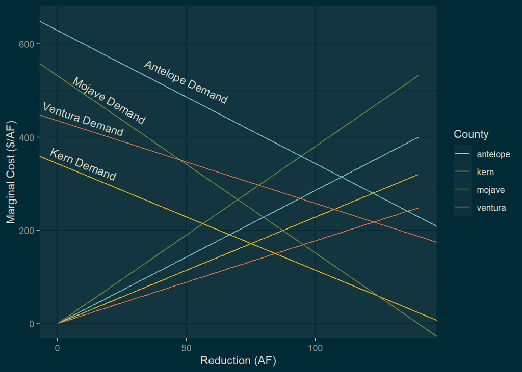

```r
# Caluclate demand curves:
# Kern (Baseline = 150) --> 2.29(A)
## 2.29(150 - A) --> 343.5 - 2.29A

reduction <- districts$reduction
kern_demand <- function(reduction){
 demand = 343.5 - 2.29*(reduction)
return(demand)
}


# Mojave (Baseline = 140) --> 3.8(A)
## 3.8(140 - A) --> 532 - 3.8A
mojave_demand <- function(reduction){
 demand = 532 - 3.8*(reduction)
return(demand)
}

# Antelope (Baseline = 220) --> 2.86(A)
## 2.86(220 - A) --> 629.2 - 2.86A

antelope_demand <- function(reduction){
 demand = 629.2 - 2.86*(reduction)
return(demand)
}

# Ventura (Baseline = 245) --> 1.78(A)
## 1.78(245 - A) --> 436.1 - 1.78A

ventura_demand <- function(reduction){
 demand = 436.1 - 1.78*(reduction)
return(demand)
}

demand_water <- seq(0,300, by = 1)
ventura_p <- ventura_demand(demand_water)
kern_p <- kern_demand(demand_water)
mojave_p <- mojave_demand(demand_water)
antelope_p <- antelope_demand(demand_water)


ggplot(data = districts_predict_clean, aes(x = reduction, y = mc)) +
  geom_line(aes(color = county, ymax = 650)) +
  scale_color_manual("County",
                     values = c('cadetblue3', 'darkgoldenrod1',
                     'darkolivegreen4', 'sienna2')) +
  geom_abline(color = "darkgoldenrod1",
              intercept = 343.5, slope= -lm_kern$coefficients) +
  annotate("text", x = 10, y = 343,
           label = "Kern Demand", angle = -22) +
  geom_abline(color = "darkolivegreen4",
              intercept = 532, slope= -lm_mojave$coefficients) +
  annotate("text", x = 20, y = 480,
           label = "Mojave Demand", angle = -30) +
  geom_abline(color = "cadetblue3",
              intercept = 629.2, slope= -lm_antelope$coefficients) +
  annotate("text", x = 50, y = 520,
           label = "Antelope Demand", angle = -25) +
  geom_abline(color = "sienna2",
              intercept = 436.1, slope= -lm_ventura$coefficients) +
  annotate("text", x = 10, y = 440,
           label = "Ventura Demand", angle = -19) +
  labs(x = "Reduction (AF)", y = "Marginal Cost ($/AF)")
```

###### *This graph shows both water demand (downward sloping lines) and marginal cost of abatement (upward sloping lines), color coded for each county.*

Based on the graph above, Antelope County is willing to pay the most for the first unit of water.

### **3. Policy Considerations**

Here we analyze three alternative policies for reducing water use among these irrigation districts. In total, these irrigation districts will need to reduce water consumption from the current 755 AF down to 500 AF.

#### **Cap Without Trade**

```r
# Cap without trade. Reduce each district’s water use by the same fraction (e.g., 1/3 of current baseline use), so the 500 AF target is met. (multiplier is 0.662)

fraction <- 0.662
kern_use_cap <- 150*fraction
#50.7 reduced
mojave_use_cap <- 140*fraction
#47.32 reduced
antelope_use_cap <- 220*fraction
#74.36 reduced
ventura_use_cap <- 245*fraction
#82.81 reduced

#mojave_cap+ventura_cap+antelope_cap+kern_cap --> This all adds up to 500 AF, the total use

# But cost is a function of abatement, so we need the abatement values instead.

kern_abate_cap <- 150-kern_use_cap
mojave_abate_cap <- 140-mojave_use_cap
antelope_abate_cap <- 220-antelope_use_cap
ventura_abate_cap <- 245-ventura_use_cap
# DON'T KNOW ABOUT STRINGENCY HERE

# Cost, plug in REDUCTION to each district's cost curve, then take the area under the marginal cost curve for each at the given price/quantity reduction

kern_price_cap <- 2.29*kern_abate_cap
kern_cost_cap <- 0.5*kern_price_cap*kern_abate_cap

mojave_price_cap <- 3.8*mojave_abate_cap
mojave_cost_cap <- 0.5*mojave_price_cap*mojave_abate_cap

antelope_price_cap <- 2.86*antelope_abate_cap
antelope_cost_cap <- 0.5*antelope_price_cap*antelope_abate_cap

ventura_price_cap <- 1.78*ventura_abate_cap
ventura_cost_cap <- 0.5*ventura_price_cap*ventura_abate_cap

total_cost_cap = ventura_cost_cap + kern_cost_cap + antelope_cost_cap + mojave_cost_cap
```

*(1)* Stringency of this policy is defined as the magnitude of the fraction for reduction. In this case, each district has to reduce water use by 33.8%.

*(2)* Total cost of this approach is $21208.

*(3)* Individual district costs are as follows:

- Kern : $2943
- Mojave: $4254
- Antelope: $7907
- Ventura: $6103

*(4)* This policy does not generate tax revenue.

Antelope County bears the highest individual cost as a result of this cap without trade policy which applies an equal fractional reduction to the baseline water use in each district.

#### **Tax on Water Use**

```r
# Tax applied to reach 500 AF level, 255 AF reduction
# Calculate aggregate demand to get the price at which cumulative water use is 500 AF

# Add together the inverse slopes of each MC curve

aggregate_cost_slope <- (1/2.29 + 1/3.8 + 1/2.86 + 1/1.78)


tax_level <- 255/aggregate_cost_slope

# Tax of $158.26/AF is applied across all counties.

# Now we need to see cost to each district, plug the price into the individual MC curves then take the area under each and sum for total.

# Kern
# tax_level = 2.29A
kern_abate_tax <- tax_level/2.29
# 69.15 AF
kern_cost_tax <- 0.5*tax_level*kern_abate_tax

# Mojave
# tax_level = 3.8A
mojave_abate_tax <- tax_level/3.8
#41.67 AF
mojave_cost_tax <- 0.5*tax_level*mojave_abate_tax

#Antelope
# tax_level = 2.86A
antelope_abate_tax = tax_level/2.86
# 55.37 AF
antelope_cost_tax <- 0.5*tax_level*antelope_abate_tax

# Ventura
# tax_level = 1.78A
ventura_abate_tax = tax_level/1.78
# 88.96
ventura_cost_tax <- 0.5*tax_level*ventura_abate_tax

#ventura_abate_tax+mojave_abate_tax+antelope_abate_tax+kern_abate_tax
# Total abatement still 255

total_cost_tax = 0.5*255*tax_level

# Revenue is the tax times the AF used.
tax_revenue <- tax_level*500
```

*(1)* Stringency of this policy is defined as the magnitude of the tax for reduction. In this case, that is equal to $158.

*(2)* Total cost of this approach is $20178.

*(3)* Individual district costs are as follows:

- Kern : $5469
- Mojave: $3295
- Antelope: $4379
- Ventura: $7035

*(4)* Tax revenue generated is $79129 based on 500AF of total use.

#### **Cap and Trade**

We also have the total cost from above as: $21208.

```r
# Given the total marginal cost, we should assume these will be set equal for firms to get the most efficient/lowest cost solution.

# THIS SHOULD BE THE SAME AS THE TAX IN TERMS OF ABATEMENT PER DISTRICT

#Kern initially abates 50.7 AF at a price/MC of $115.6, they use 99.3 AF
#Mojave initially abates 42.73 AF at price/MC of $107.89, they use 92.7 AF
#Antelope initially abates 74.36 AF at price/MC of $169.54, they use 145.6 AF
#Ventura initially abates 82.8 AF at price/MC of $188.8, they use 162.2 AF

# Use post-quota could probably be considered their "allocations"/"rights"

# Still need to abate 255 AF total, but Mojave and Kern will likely face higher relative MC while Antelope and Ventura will face slightly lower MC.

trade_mc <- tax_level

#Kern Q with trade
kern_abate_trade <- trade_mc/2.29
#69.15 AF is abatement level (far higher than initial)

#Mojave Q with trade
mojave_abate_trade <- trade_mc/3.8
#41.67 AF is new abatement level (almost same as initial)

#Antelope Q with trade
antelope_abate_trade <- trade_mc/2.86
#55.37 AF is new abatement level (far below initial)

#Ventura Q with trade
ventura_abate_trade <- trade_mc/1.78
#88.96 AF is new abatement level (higher than initial)

#ventura_abate_trade+antelope_abate_trade+mojave_abate_trade+kern_abate_trade

# Same allocation/cost as efficient tax, different revenue implications. MC for abatement is the same for each district at these allocations.

#ventura_cost_cap/ventura_abate_cap
#ventura_cost_tax/ventura_abate_trade
# MC lower compared to cap

#antelope_cost_cap/antelope_abate_cap
#antelope_cost_tax/antelope_abate_trade
# MC Lower compared to cap

#kern_cost_cap/kern_abate_cap
#kern_cost_tax/kern_abate_trade
# MC higher compared to cap

#mojave_cost_cap/mojave_abate_cap
#mojave_cost_tax/mojave_abate_trade
# MC higher compared to cap

total_cost_trade<- 0.5*trade_mc*255
```

*(2)* Total cost of this approach is $20178 (same as tax). This is $1030 lower than the cost of the cap with no trade.

*(3)* Individual district costs are as follows (the baseline is the same as the tax but we are assuming the ones that have to abate more are paid by the ones that abate less - baseline is subtracted by the change in abatement multiplied by the credit price):

- Kern : $2545
- Mojave: $4188
- Antelope: $7382
- Ventura: $6059

*(4)* No tax revenue is generated from this policy. Instead, some districts may pay others to increase abatement more so they can use more water. It can be assumed that the per unit price of AF for the trade value is the same as the tax amount, which is $158 per AF. It is presumed that districts with lower costs under the cap and trade scenario (Mojave and Antelope) would compensate districts with higher costs (Kern and Ventura) to incentivize them to abate more.

### **4. Drought Sensitivity**

A severe drought hits California, and it is necessary to reduce water use from 500 AF down to 300 AF. We now estimate the cost of the drought (i.e., the cost of reducing water use from 500 AF to 300 AF) to each irrigation district under each policy. Considering the entire jump from status quo (755 AF) to the drought (300 AF), we determine which policy is preferred by each irrigation district.

#### **Drought + Cap Without Trade**

```r
# Cap without trade. Reduce each district’s water use by the same fraction, so the 300 AF target is met. (multiplier is 0.397)

fraction_drought <- 0.397
kern_use_d <- 150*fraction_drought

mojave_use_d <- 140*fraction_drought

antelope_use_d <- 220*fraction_drought

ventura_use_d <- 245*fraction_drought


# But cost is a function of abatement, so we need the abatement values instead.

kern_abate_cap_d <- 150-kern_use_d
mojave_abate_cap_d <- 140-mojave_use_d
antelope_abate_cap_d <- 220-antelope_use_d
ventura_abate_cap_d <- 245-ventura_use_d
# DON'T KNOW ABOUT STRINGENCY HERE

# Cost, plug in REDUCTION to each district's cost curve, then take the area under the marginal cost curve for each at the given price/quantity reduction

kern_price_cap_d <- 2.29*kern_abate_cap_d
kern_cost_cap_d <- 0.5*kern_price_cap_d*kern_abate_cap_d

mojave_price_cap_d <- 3.8*mojave_abate_cap_d
mojave_cost_cap_d <- 0.5*mojave_price_cap_d*mojave_abate_cap_d

antelope_price_cap_d <- 2.86*antelope_abate_cap_d
antelope_cost_cap_d <- 0.5*antelope_price_cap_d*antelope_abate_cap_d

ventura_price_cap_d <- 1.78*ventura_abate_cap_d
ventura_cost_cap_d <- 0.5*ventura_price_cap_d*ventura_abate_cap_d

total_cost_cap_d = ventura_cost_cap_d + kern_cost_cap_d + antelope_cost_cap_d + mojave_cost_cap_d
```

*(1)* Total cost of this approach is $67499.

*(2)* Individual district costs are as follows:

- Kern : $9367
- Mojave: $13541
- Antelope: $25166
- Ventura: $19425

Antelope County bears the highest individual cost as a result of this drought and cap without trade policy which applies an equal fractional reduction to the baseline water use in each district.

#### **Drought + Tax on Water Use**

```r
# Tax applied to reach 300 AF level, 455 AF reduction
# Calculate aggregate demand to get the price at which cumulative water use is \300 AF

# Same aggregate cost slope as above

tax_level_d <- 455/aggregate_cost_slope

# Tax of $282.38/AF is applied across all counties.

# Now we need to see cost to each district, plug the price into the individual MC curves then take the area under each and sum for total.

# Kern
# tax_level = 2.29A
kern_abate_tax_d <- tax_level_d/2.29
# 123.3 AF
kern_cost_tax_d <- 0.5*tax_level_d*kern_abate_tax_d

# Mojave
# tax_level = 3.8A
mojave_abate_tax_d <- tax_level_d/3.8
#74.31 AF
mojave_cost_tax_d <- 0.5*tax_level_d*mojave_abate_tax_d

#Antelope
# tax_level = 2.86A
antelope_abate_tax_d = tax_level_d/2.86
# 98.74 AF
antelope_cost_tax_d <- 0.5*tax_level_d*antelope_abate_tax_d

# Ventura
# tax_level = 1.78A
ventura_abate_tax_d = tax_level_d/1.78
# 158.64 AF
ventura_cost_tax_d <- 0.5*tax_level_d*ventura_abate_tax_d

#ventura_abate_tax_d+mojave_abate_tax_d+antelope_abate_tax_d+kern_abate_tax_d
# Total abatement 455

total_cost_tax_d = 0.5*455*tax_level_d

# Revenue is the tax times the AF used.
tax_revenue_d <- tax_level_d*300
```

*(1)* Total cost of this approach is $64242.

*(2)* Individual district costs are as follows:

- Kern : $17411
- Mojave: $10492
- Antelope: $13941
- Ventura: $22399

*(3)* Tax revenue generated is $84715 based on 300AF of total use. This is slightly higher than the tax revenue for the non-drought scenario.

This policy would likely not be favored by Kern since it would essentially wipe out their water consumption.

#### **Drought + Cap and Trade**

From part (a), we have the cost to each district for the cap without trade as:

- Kern : $9367, reduction of 90.45 AF. This leaves Kern’s total post-drought use as 59.55 AF.
- Mojave: $13541, reduction of 84.42 AF. This leaves Mojave’s total post-drought use as 55.58 AF.
- Antelope: $25166, reduction of 132.66 AF. This leaves Antelope’s total post-drought use as 87.34 AF.
- Ventura: $19425, reduction of 147.74 AF. This leaves Ventura’s total post-drought use as 97.265 AF.

We also have the total cost from above as: $67499.

```r
# Still need to abate 455 AF total, but Mojave and Kern will likely face higher relative MC while Antelope and Ventura will face slightly lower MC.

trade_mc_d <- tax_level_d

#Kern Q with trade
kern_abate_trade_d <- trade_mc_d/2.29
#kern_abate_cap_d - kern_abate_trade_d
#32.86 increase in abatement

#Mojave Q with trade
mojave_abate_trade_d <- trade_mc_d/3.8
#mojave_abate_cap_d-mojave_abate_trade_d
#-10.11 decrease in abatement

#Antelope Q with trade
antelope_abate_trade_d <- trade_mc_d/2.86
#antelope_abate_cap_d-antelope_abate_trade_d
#-33.92 decrease in abatement

#Ventura Q with trade
ventura_abate_trade_d <- trade_mc_d/1.78
#ventura_abate_cap_d-ventura_abate_trade_d
#10.91 increase in abatement

# Same allocation/cost as efficient tax, different revenue implications. MC for abatement is the same for each district at these allocations.

total_cost_trade_d<- 0.5*trade_mc_d*455
```

*(1)* Total cost of this approach is $64242 (same as tax). This is $3257 lower than the cost of the cap with no trade.

*(2)* Individual district costs are as follows (same as the tax - abatement change * credit price):

- Kern : $8131 **Based on cost alone, Kern will prefer cap and trade.**
- Mojave: $13347 **Based on cost alone, Mojave will prefer the tax.**
- Antelope: $23519 **Based on cost alone, Antelope will prefer the tax**
- Ventura: $19318 **Based on cost alone, Ventura will prefer cap and trade**

**No district will chose cap with no trade**

*(3)* No tax revenue is generated from this policy. Instead, some districts may pay others to increase abatement more so they can use more water. The per unit price of AF for the trade value is the same as the tax amount, which is $282 per AF. It is presumed that districts with lower costs under the cap and trade scenario (Mojave and Antelope) would compensate districts with higher costs (Kern and Ventura) to incentivize them to abate more and offset some of their costs.